# Examples

Richel J.C. Bilderbeek

2018-09-19

# Examples

For all examples, do load `babette`:

```r
library(babette)
```

All these examples assume that `BEAST2` is installed at the default location at /home/plaintext/.local/share/beast/lib/beast.jar.

All examples read the alignment from a FASTA file (usually `my_fasta.fas`). Instead of a full run, the MCMC chain length is shortened to 10K states, with a measurement every 1K states:

```r
mcmc <- create_mcmc(chain_length = 10000, store_every = 1000)
```

## Example #1: all default

Using all default settings, only specify a DNA alignment.

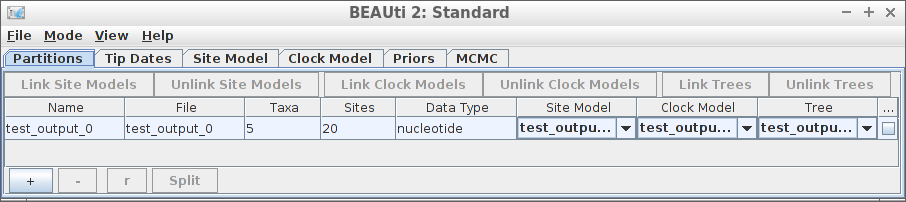

Example #1: all default

```r
posterior <- bbt_run(
  "test_output_0.fas",
  mcmc = mcmc
)
```

All other parameters are set to their defaults, as in BEAUti.

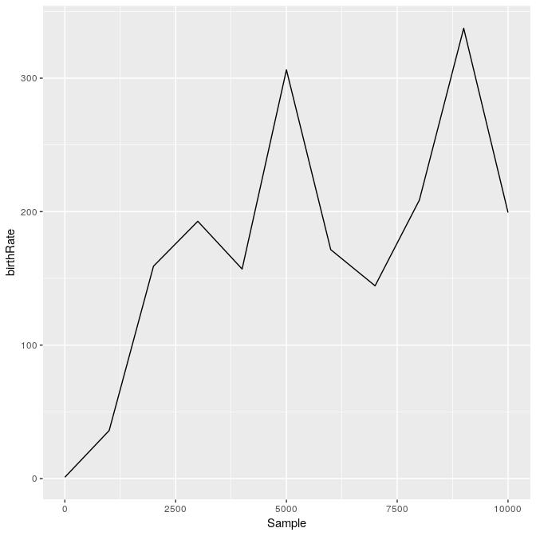

```r
ggplot2::ggplot(
  data = posterior$estimates,
  ggplot2::aes(x = Sample)
) + ggplot2::geom_line(ggplot2::aes(y = birthRate))
```

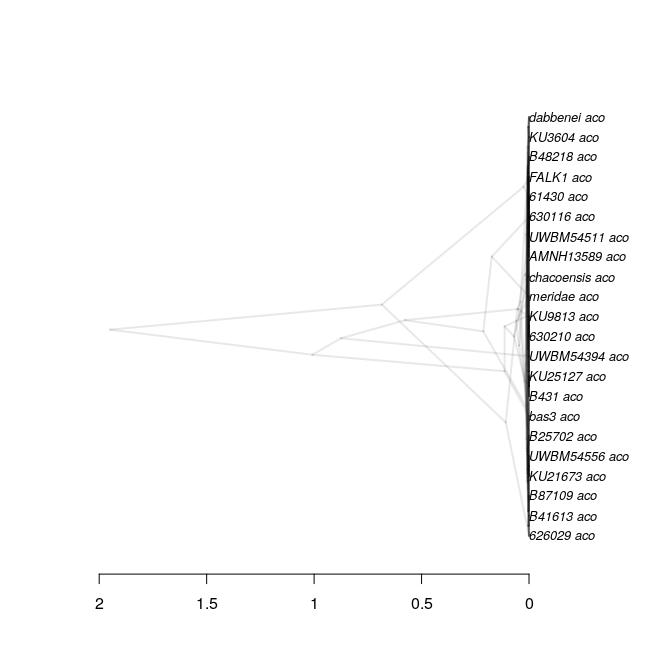

```r
plot_densitree(posterior$test_output_0_trees, width = 2)
```

## Example #2: fixed crown age

Using all default settings, only specify a DNA alignment.

```
[No screenshot, as this cannot be done in BEAUti yet]
```

```r
posterior <- bbt_run(
  "my_fasta.fas",
  posterior_crown_age = 15,
  mcmc = mcmc
)
```

`fasta_to_phylo` creates a random phylogeny from a FASTA file of a certain crown age.

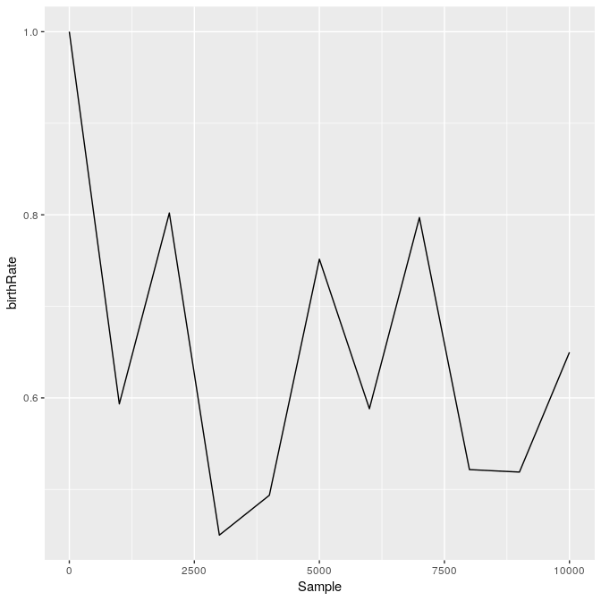

```r
ggplot2::ggplot(
  data = posterior$estimates,
  ggplot2::aes(x = Sample)
) + ggplot2::geom_line(ggplot2::aes(y = birthRate))
```

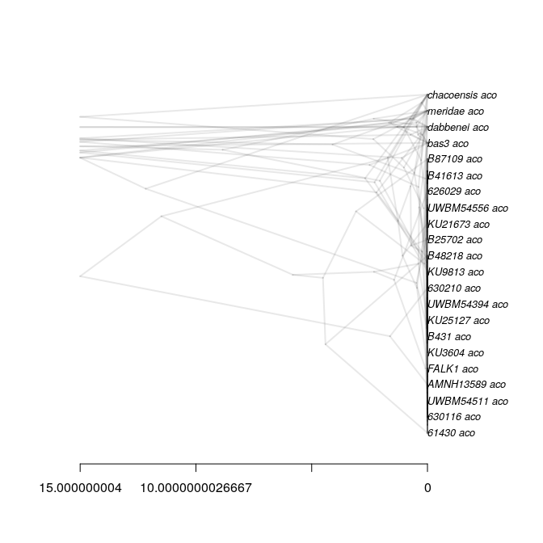

[figure not shown]

```r
plot_densitree(posterior$my_fasta_trees, width = 2)
```

```r
posterior <- bbt_run(
  "my_fasta.fas",
  mcmc = mcmc,
  mrca_priors = create_mrca_prior(
    taxa_names = sample(get_taxa_names("my_fasta.fas"), size = 3),
    alignment_id = get_alignment_id("my_fasta.fas"),
    is_monophyletic = TRUE,
    mrca_distr = create_normal_distr(
      mean = create_mean_param(value = 15.0, estimate = FALSE),
      sigma = create_sigma_param(value = 0.025, estimate = FALSE)
    )
  )
)
```

Here we use an MRCA prior with fixed (non-estimated) values of the mean and standard deviation for the common ancestor node’s time.

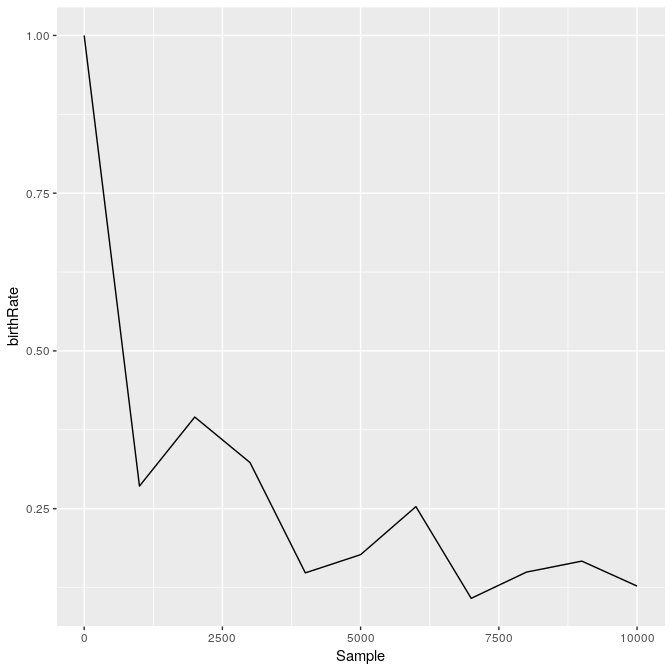

```r
ggplot2::ggplot(
  data = posterior$estimates,
  ggplot2::aes(x = Sample)
) + ggplot2::geom_line(ggplot2::aes(y = birthRate))
```

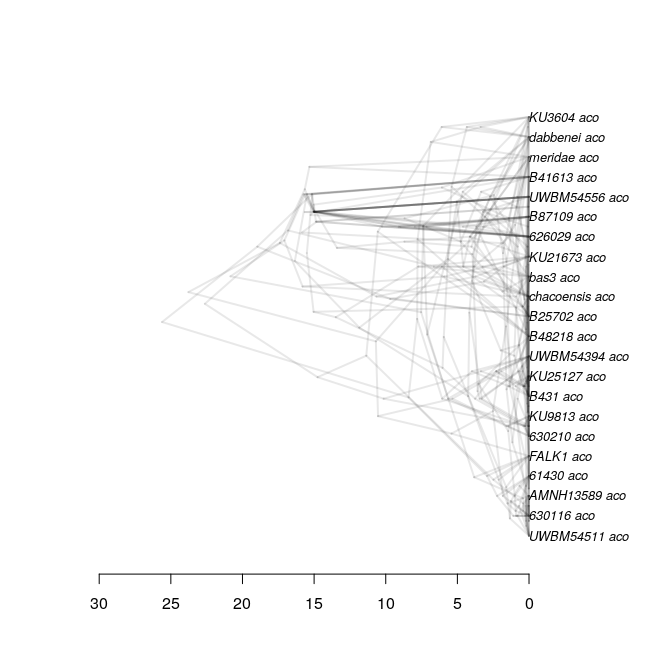

```r
plot_densitree(posterior$my_fasta_trees, width = 2)
```

## Example #3: JC69 site model

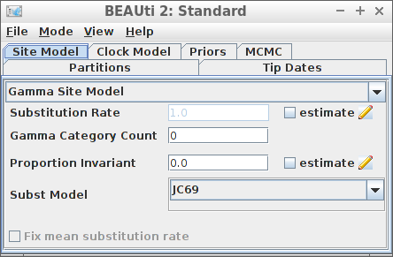

Example #3: JC69 site model

```r
posterior <- bbt_run(
  "my_alignment.fas",
  site_models = create_jc69_site_model(),
  mcmc = mcmc
)
```

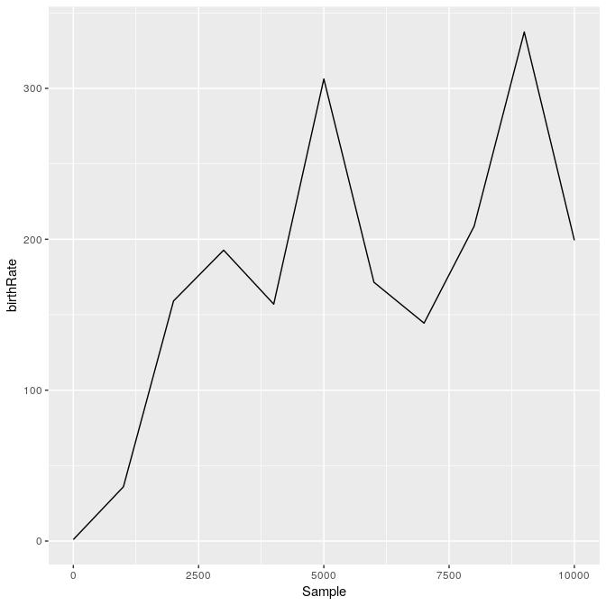

```r
ggplot2::ggplot(
  data = posterior$estimates,
  ggplot2::aes(x = Sample)
) + ggplot2::geom_line(ggplot2::aes(y = birthRate))
```

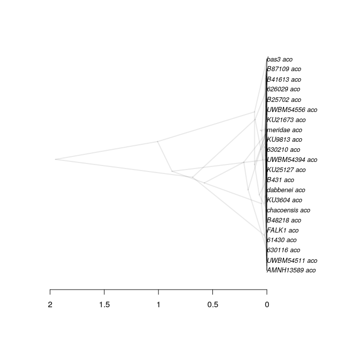

```r
plot_densitree(posterior$my_alignment_trees, width = 2)
```

## Example #4: Relaxed clock log normal

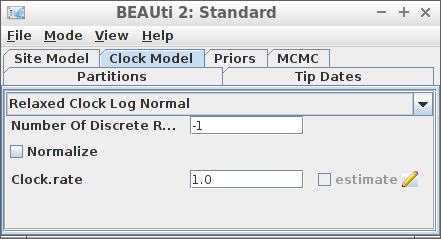

Example #4: Relaxed clock log normal

```r
posterior <- bbt_run(
  "my_alignment.fas",
  clock_models = create_rln_clock_model(),
  mcmc = mcmc
)
```

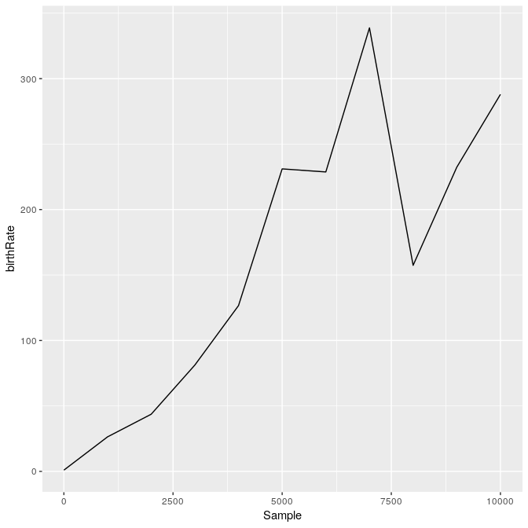

```r
ggplot2::ggplot(
  data = posterior$estimates,
  ggplot2::aes(x = Sample)
) + ggplot2::geom_line(ggplot2::aes(y = birthRate))
```

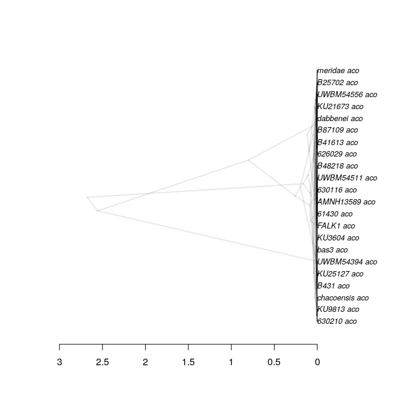

```r
plot_densitree(posterior$my_alignment_trees, width = 2)
```

## Example #5: Birth-Death tree prior

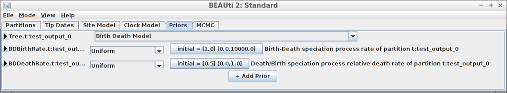

Example #5: Birth-Death tree prior

```r
posterior <- bbt_run(
  "my_alignment.fas",
  tree_priors = create_bd_tree_prior(),
  mcmc = mcmc
)
```

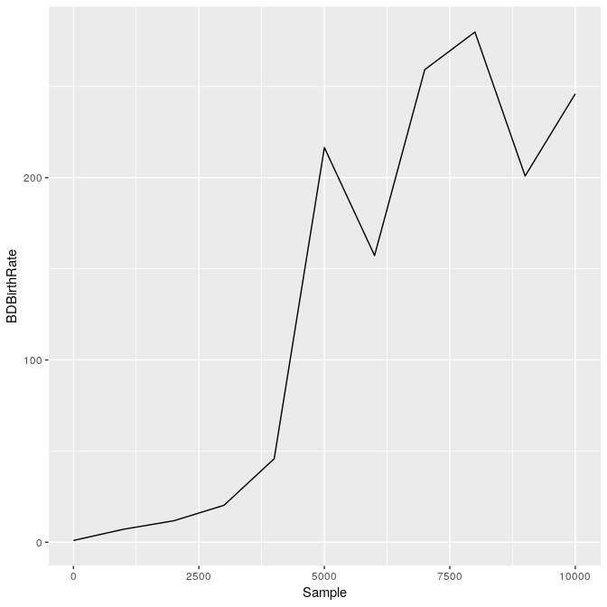

```r
ggplot2::ggplot(
  data = posterior$estimates,
  ggplot2::aes(x = Sample)
) + ggplot2::geom_line(ggplot2::aes(y = BDBirthRate))
```

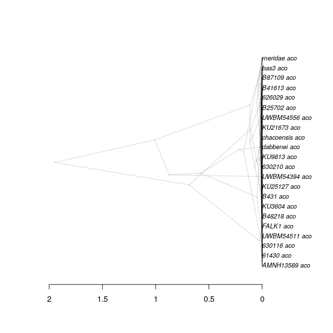

```r
plot_densitree(posterior$my_alignment_trees, width = 2)
```

## Example #6: Yule tree prior with a normally distributed birth rate

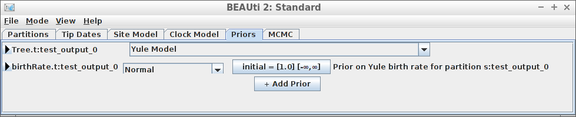

Example #6: Yule tree prior with a normally distributed birth rate

```r
posterior <- bbt_run(
  "my_alignment.fas",
  tree_priors = create_yule_tree_prior(
    birth_rate_distr = create_normal_distr(
      mean = create_mean_param(value = 1.0),
      sigma = create_sigma_param(value = 0.1)
    )
  ),
  mcmc = mcmc
)
```

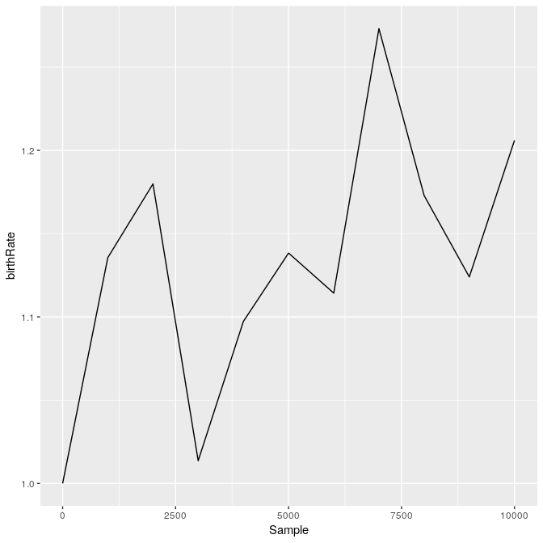

```r
ggplot2::ggplot(
  data = posterior$estimates,
  ggplot2::aes(x = Sample)
) + ggplot2::geom_line(ggplot2::aes(y = birthRate))
```

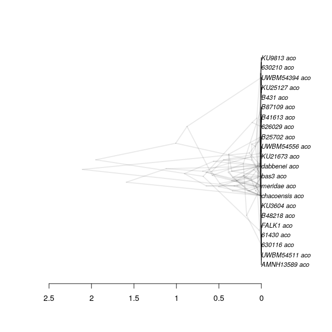

```r
plot_densitree(posterior$my_alignment_trees, width = 2)
```

Thanks to Yacine Ben Chehida for this use case

## Example #7: HKY site model with a non-zero proportion of invariants

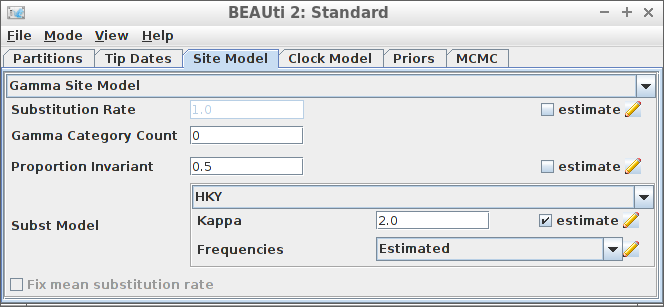

Example #7: HKY site model with a non-zero proportion of invariants

```r
posterior <- bbt_run(
  "my_alignment.fas",
  site_models = create_hky_site_model(
    gamma_site_model = create_gamma_site_model(prop_invariant = 0.5)
  ),
  mcmc = mcmc
)
```

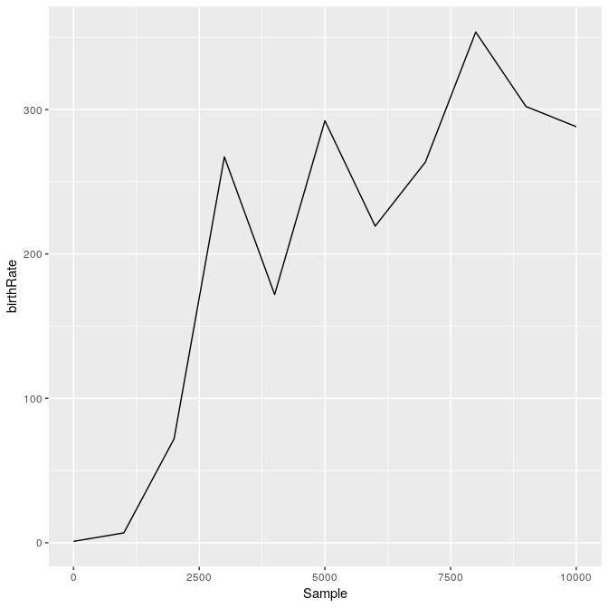

```r
ggplot2::ggplot(
  data = posterior$estimates,
  ggplot2::aes(x = Sample)
) + ggplot2::geom_line(ggplot2::aes(y = birthRate))
```

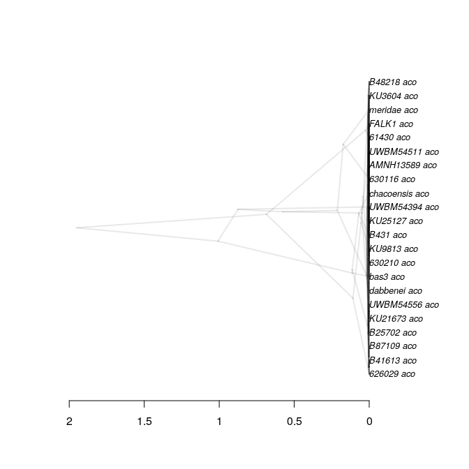

```r
plot_densitree(posterior$my_alignment_trees, width = 2)
```

Thanks to Yacine Ben Chehida for this use case

## Example #8: Strict clock with a known clock rate

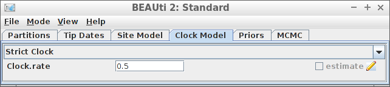

Example #8: Strict clock with a known clock rate

```r
posterior <- bbt_run(
  "my_alignment.fas",
  clock_models = create_strict_clock_model(
    clock_rate_param = create_clock_rate_param(value = 0.5)
  ),
  mcmc = mcmc
)
```

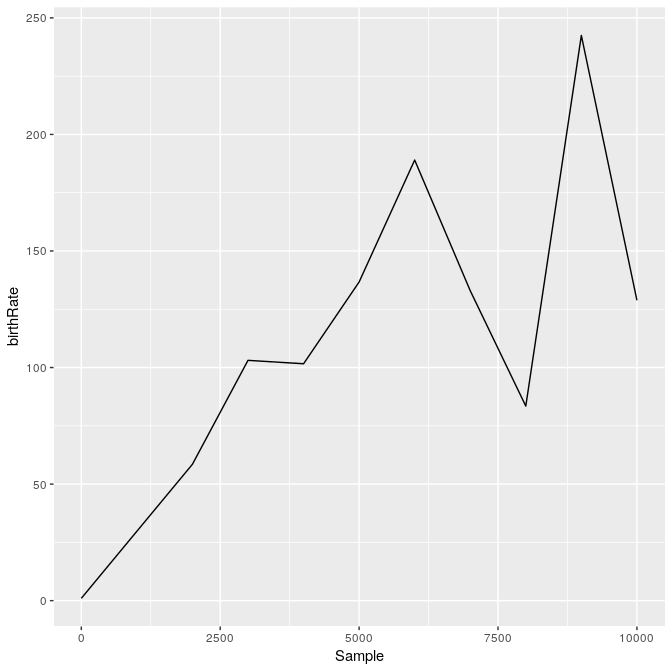

```r
ggplot2::ggplot(
  data = posterior$estimates,
  ggplot2::aes(x = Sample)
) + ggplot2::geom_line(ggplot2::aes(y = birthRate))
```

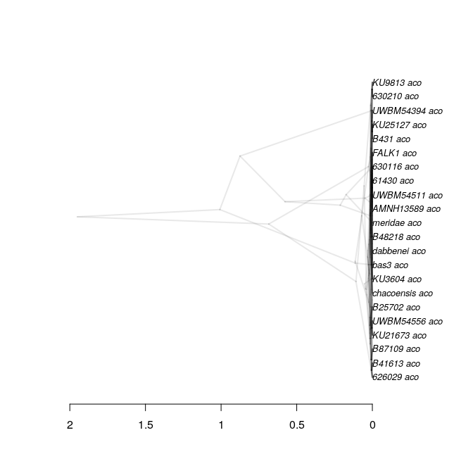

```r
plot_densitree(posterior$my_alignment_trees, width = 2)
```

Thanks to Paul van Els and Yacine Ben Chehida for this use case.

## Example #9: Two alignments

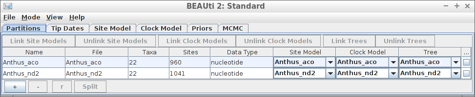

Example 9: Two alignments

```r
posterior <- bbt_run(
  c("anthus_aco.fas", "anthus_nd2.fas"),
  mcmc = mcmc
)
```

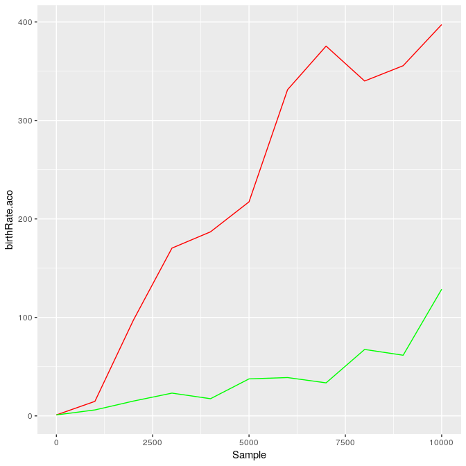

```r
ggplot2::ggplot(
  data = posterior$estimates,
  ggplot2::aes(x = Sample)
) + ggplot2::geom_line(ggplot2::aes(y = birthRate.aco), color = "red") +
  ggplot2::geom_line(ggplot2::aes(y = birthRate.nd2), color = "green")
```

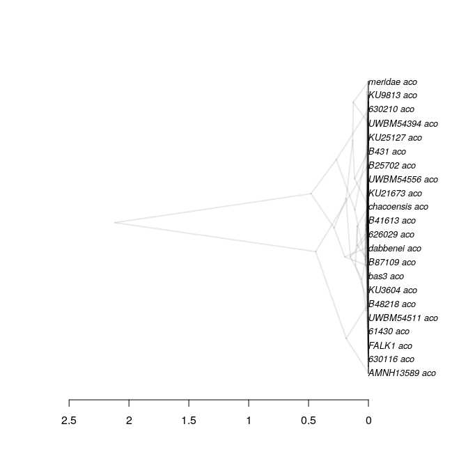

```r
plot_densitree(posterior$anthus_aco_trees, width = 2)
```

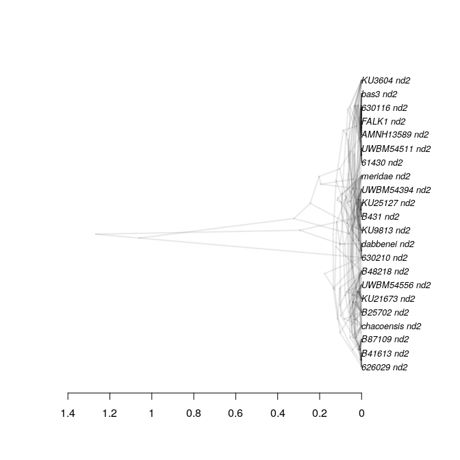

```r
plot_densitree(posterior$anthus_nd2_trees, width = 2)
```

Thanks to Paul van Els for this use case and supplying these FASTA files.

## Example #10: Two alignments, different site models

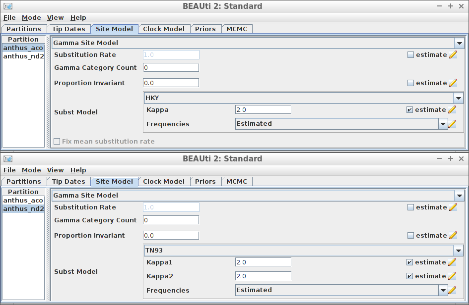

Example 10: Two alignments, different site models

```r
posterior <- bbt_run(
  c("anthus_aco.fas", "anthus_nd2.fas"),
  site_models = list(
    create_hky_site_model(),
    create_tn93_site_model()
  ),
  mcmc = mcmc
)
```

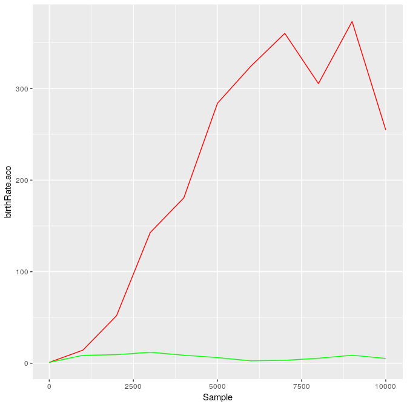

```r
ggplot2::ggplot(
  data = posterior$estimates,
  ggplot2::aes(x = Sample)
) + ggplot2::geom_line(ggplot2::aes(y = birthRate.aco), color = "red") +
  ggplot2::geom_line(ggplot2::aes(y = birthRate.nd2), color = "green")
```

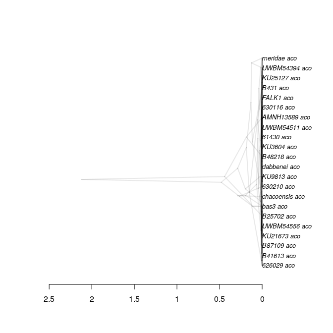

```r
plot_densitree(posterior$anthus_aco_trees, width = 2)
```

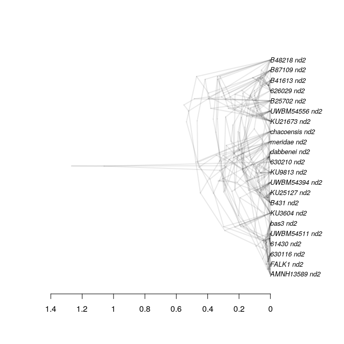

```r
plot_densitree(posterior$anthus_nd2_trees, width = 2)
```

Since `v1.12` this it is supported to have two alignments with different site models, clock models and tree priors.

Thanks to Paul van Els for this use case.